# 03 일원배치법

## 03.01. 일원배치법

- **한 인자에서 3개 이상의 처리에서 모평균의 차이가 있는지를 비교**
  - **특성값에 영향을 미치는 다양한 요인 중에서 특히 알고 싶은 특정 요인의 영향을 조사하고자 할 경우**
  - **특성값에 영향을 미치는 여러 요인에 대한 검증이 어늦 정도 진척되고, 이들 요인 중에서 특성값에 큰 영향을 미칠 것으로 예상되는 특정한 한 요인의 영향을 조사하고자 할 경우**
- 처리를 받는 대상 또는 **실험환경인 실험단위가 모두 동질적**이라는 가정에서 출발하므로, 처리를 실험단위에 배치할 때 제한조건이 없음
  - 일원배치법은 수준수와 반복수에 제한이 없으며, 결측치가 있어도 분석이 용이
- **일원배치법은 처리를 실험단위에 배치하는 순서 또는 실험실시의 순서를 랜덤하게 결정하므로, 완전확률화계획**
  - 실험자는 회피할 수 없는 외부요인들의 영향을 상쇄시키고, 실험자료들이 독립이라는 가정을 충족

### 요인수준의 선택

1. **실험자가 스스로 특정한 실험수준을 선택**
- **요인의 수준이 고정, 고정요인에 대응되는 모형을 고정모형(모수모형)**
  - **고정요인의 예 : 온도, 압력, 품종 등**
  - 각 수준이 기술적인 의미를 가짐 $\rightarrow$ 특정 수준에서의 효과와 최적조건을 구하는데 관심
2. **특정 범위 내에서 임의로 선택 (랜덤)**
- **요인의 수준이 랜덤하게 선정, 랜덤요인에 대응되는 모형을 랜덤모형 (변량모형)**
  - 랜덤요인 예 : 원자재 로트, 실험일, 작업자 등
  - 이 경우 특정한 수준에서의 반응치가 기술적인 의미를 갖지 못함 $\rightarrow$ 수준 간의 산포의 크기인 분산성분에 관심

| 인자 (인자의 수준) | 실험의 반복 | 합계 | 평균 |
| --- | --- | --- | --- |
| $A_1$ | $x_{11}$...$x_{1r}$ | $T_1$ | $\bar{x_1}$ |
| $\vdots$ | $\vdots$ | $\vdots$ | $\vdots$ |
| $A_1$ | $x_{11}$...$x_{1r}$ | $T_1$ | $\bar{x_1}$ |
|  |  | $T$ | $\bar{\bar{x}}$ |

- $T_i$와 $\bar{x_i}$는 수준 $A_i$에서 실험된 $r$개의 데이터의 합과 평균이며, $T$와 $\bar{\bar{x}}$는 $ar$개 전체 데이터의 합과 평균
- **요인 $A$가 고정요인일 때, $a$개의 수준 간 효과에 차이가 있는지를 분석하기 위하여 각 수준에 대한 모집단 모형이 필요**
  - **각각의 수준에 해당하는 $a$개의 모집단이 서로 독립적이고, 평균이 $\mu_i$, 공통분산 $\sigma^2_E$를 갖는 정규분포를 따른다고 가정하여, 가설을 검정**

$$H_0:\mu_1 = \dots = \mu_a$$$$H_1:not\;H_0$$

- 모집단 가정에 의하여 $x_{ij}$는 $x_{ij} = \mu_i + \epsilon_{ij}$
  - $\epsilon_{ij}$는 실험오차에 해당되는 확률변수로서, 평균 0, 분산 $\sigma^2_E$인 정규분포를 따른다고 가정
- 실험전체의 모평균이 $\mu$라 하면 $\mu$는

$$\mu= {{\sum^a_{i=1}\mu_i}\over{a}}$$

- i번째 수준의 모평균 $\mu_i$는 실험전체의 모평균 $\mu$와 i번째 처리에서의 순수효과 (pure effect)인 $\alpha_i$의 합으로 나타낼 수 있으므로, $\mu_i = \mu + \alpha_i$로 대체하면, 일원배치 데이터의 구조모형은

$$x_{ij} = \mu + \alpha_i+\epsilon_{ij},\;\;\;i=1, 2, \dots,a;\;\;\;j=1,2,\dots,r$$

- $\mu$는 전체모평균이고, $\alpha_i$는 요인 $A$의 순수효과로서 $\sum\alpha_i=0$이고, $\epsilon_{ij}$는 오차항으로 서로 독립인 $N(0, \sigma^2_E$)을 따름

#### 일원배치법 구조모형에서 오차 $\epsilon_{ij}$에 대한 가정은 다음 4가지

1. **정규성 : 오차 $\epsilon_{ij}$의 분포는 정규분포를 따름**
2. **독립성 : 오차는 서로 독립**
3. **불편성 : 오차의 기댓값은 0으로 치우침(bias)가 없다**
4. **등분산성 : 오차 $\epsilon{ij}$의 분산은 $\sigma^2_E$으로 요인의 어떤 수준에서든 특성치의 분산은 일정**

## 03.02. 분산분석

- a개의 모평균에 차이가 있는지를 거정하는 것은 a개의 수준효과 간 차이가 있는지 검정하는 것과 같으므로 가설은
  - 자료의 총변동을 급간변동과 급내변동으로 분해하여 요인의 여러 수준이 특성값에 유의한 영향을 미치는지 탐색

$$H_0 :\alpha_1=\dots,\alpha_a=0$$$$H_1 : not\;H_0$$

#### 분산분석은 데이터의 총변동을 나누어 각 요인의 영향력을 탐색하는 것

### 총변동의 분할

- 변동을 정의하기 위해, 어느 점으로부터의 산포인가를 나타내는 자료의 중심과 각 자료가 중심으로부터 얼마나 떨어져 있는가를 나타내는 거리의 개념이 필요

  $\rightarrow$ 특성값 $x_{ij}$의 총평균 $\bar{\bar{x}}$로부터의 거리인 총편차 $x_{ij} - \bar{\bar{x}}$는 $\alpha_i$에 기인하는 편차와 같은 수준에서 반복실험 하였을 때 생기는 잔차로 다음과 같이 분해

$$x_{ij}-\bar{\bar{x}}= (\bar{x_i}-\bar{\bar{x}}) + (x_{ij}-\bar{x_i})$$$$총편차=(\alpha_i에\;기인하는\;편차)+(잔차)$$

- 양변을 동시에 제곱하여 전체 $ar$개의 데이터의 제곱합을 계산

$$\sum_i \sum_j (x_{ij}-\bar{\bar{x}})^2= \sum_i r(\bar{x_i}-\bar{\bar{x}})^2 + \sum_i \sum_j (x_{ij}-\bar{x_i})^2$$$$총변동=급간변동+급내변동$$$$SS_T = SS_A + SS_E$$

- 총변동은 요인 $A$에 의한 변동과 잔차변동으로 분할

#### $CT(=수정항) = {{T^2}\over{ar}},\;\;\;T = \sum^a_{i=1}\sum^r_{j=1}x_{ij}$일 때,

$$SS_T = \sum_i \sum_j x^2_{ij} - CT$$$$SS_A = \sum_i {{T^2_{i.}}\over{r}} - CT$$$$SS_E = SS_T - SS_A$$

### 자유도의 분할

- **각 제곱합의 자유도는 제곱을 한 편차의 개수에서 선형제약조건의 수를 뺸 것**

| 제곱합 | 편차의 개수 | 선형제약조건 | 자유도 |
| --- | --- | --- | --- |
| $SS_T$ | ar | $\sum_i \sum_j (x_{ij}$-$\bar{\bar{x}})$=0 | $\phi_T$ = $ar$-$1$ |
| $SS_A$ | a | $\sum_i (\bar{x_{i.}}$-$\bar{\bar{x}})$=0 | $\phi_A$ = $a$-$1$ |
| $SS_E$ | ar | $\sum_i \sum_j (x_{ij}$-$\bar{x_i})$=0 ($i$=1,2..., a) | $\phi_E$ = $a$$(r$-$1)$ |

**총제곱합의 자유도 $\Phi_T$는 총변도이 원인별로 분할 되는 것과 마찬가지로 처리제곱합의 자유도 $\Phi_A$와 잔차제곱합의 자유도 $\Phi_E$로 분할 됨**

$$\phi_T = \phi_A + \phi_E$$

### 평균제곱의 기댓값과 F검정

- **평균제곱 (MS : Mean Square)은 자유도 1개당 제곱합을 의미**

$$MS_A = {{SS_A}\over{a-1}}$$$$MS_E = {{SS_E}\over{a(r-1)}}$$

- 요인 A의 평균제곱 $MS_A$와 잔차의 평균제곱 $MS_E$의 기댓값은

$$E(MA_A) = \sigma^2_E + \sum^a_{i=1} {{\alpha^2_i}\over{a-1}}$$$$E(MA_E) = \sigma^2_E$$

- **잔차의 평균제곱 $MS_E$는 $\sigma^2_E$의 불편추정량**
- **요인 $A$의 평균제곱 $MS_A$는 귀무가설 $H_0:\alpha_1=\dots=\alpha_a=0$하에서는 $E(MS_A)=\sigma^2_E$가 됨으로서, $\sigma^2_E$의 불편추정량이 되지만**

  **귀무가설이 성립하지 않으면 $MS_A$의 기댓값이 $\sigma^2_E$보다 더 크게 됨**

  **따라서, 귀무가설 $H_0 :\alpha_1=\dots,\alpha_a=0$에 대한 검정통계량은, 두 평균제곱의 비율인**

  **$$F_0 = {{MS_A}\over{MS_E}}$$가 되고, $F_0$이 커지면 귀무가설을 기각**
- 또한 귀무가설이 사실일 때, 검정통계량 $F_0$은 자유도 $(\phi_A, \phi_E)$인 F분포를 따름

  따라서, 대립가설이 옳을 때 $MS_A$가 $MS_E$보다 상대적으로 클 것이므로, 귀무가설의 기각역은

  $$F_0 > F(\phi_A, \phi_E;\;\;\alpha)$$

### 분산분석표

- **$F_0$의 값이 $F(a-1, a(r-1);\;\;\alpha)$보다 크게 되어 귀무가설을 기각할 때,**

  **요인이 특성값에 유의한 영향을 미친다고 말하며, 요인의 어떤 수준들 간에는 차이가 있다고 통계적으로 결론**

| 요인 | 제곱합 | 자유도 | 평균제곱 | $F_0$ | $F(\alpha)$ |
| --- | --- | --- | --- | --- | --- |
| $A$ | $SS_A$ | $a$-$1$ | $MS_A$ | ${{MS_A}\over{MS_E}}$ | $F(a-1, a(r-1);\;\;\alpha)$ |
| $E$ | $SS_E$ | $a(r$-$1)$ | $MS_E$ |  |  |
| $T$ | $SS_T$ | $ar$-$1$ |  |  |  |

### 의류회사 예시

- 납품업체 $A_1, \dots A_4$의 제품을 마모도의 측면 **(고정요인)**에서 비교

```r
library(tidyverse)
```

```r
a1 = c(1.93, 2.38, 2.20, 2.25)
a2 = c(2.55, 2.72, 2.75, 2.70)
a3 = c(2.40, 2.68, 2.32, 2.28)
a4 = c(2.33, 2.38, 2.28, 2.25)
wear = c(a1, a2, a3, a4)
group = c("a1", "a2", "a3", "a4"); group <- rep(group, c(4, 4, 4, 4))

wear.dat <- data.frame(group, wear)
wear.dat %>% head
```

A data.frame: 6 × 2

|  | group <chr> | wear <dbl> |
| --- | --- | --- |
| 1 | a1 | 1.93 |
| 2 | a1 | 2.38 |
| 3 | a1 | 2.20 |
| 4 | a1 | 2.25 |
| 5 | a2 | 2.55 |
| 6 | a2 | 2.72 |

#### 정규성 검정

1. **Shpiro-Wilks test : 표본수가 2000미만인 데이터셋에 적합한 정규성 검정**
2. **Kolmogorove-Smirov test : 표본수가 2000 초과인 데이터셋에 적합한 정규성 검정**
3. **Quantile-Quantile plot (Grpahic test) : 데이터셋이 정규분포를 따르는지 판단하는 시각적 분석방법**
- 분석할 데이터 종류가 많지 않다면, Q-Q plot을 통해 시각적으로 확인하는 것이 가장 간단하고 직관적

$H_0 : 데이터는\;정규성을\;만족한다$

$H_1 : not\;H_0$

- 귀무가설 기각 불가 $\rightarrow$ 데이터는 정규성을 만족

```r
shapiro.test(x = wear.dat$wear)
```

```
	Shapiro-Wilk normality test

data:  wear.dat$wear
W = 0.92118, p-value = 0.1762
```

```r
# ks.test(x = unique(wear.dat$wear), "pnorm")
```

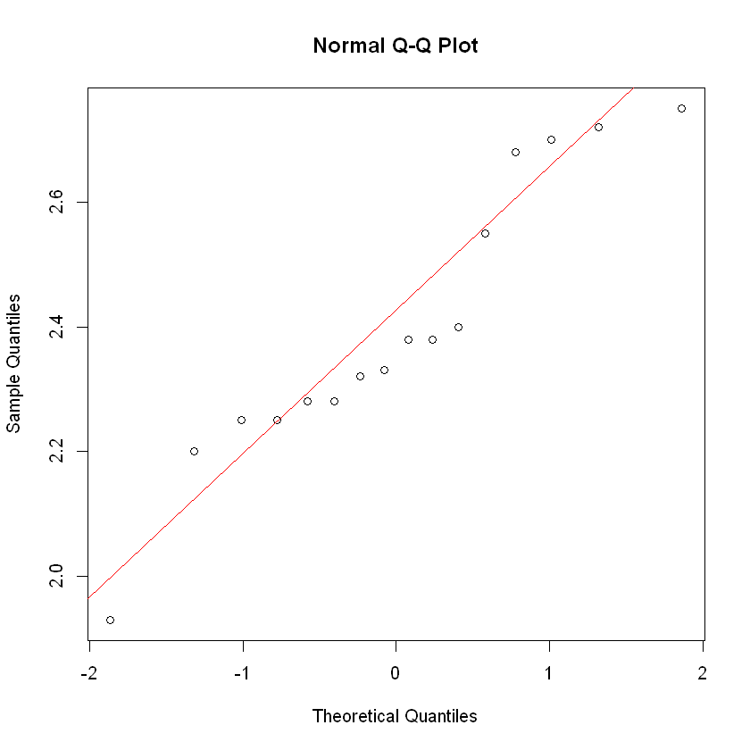

```r
qqnorm(wear.dat$wear); qqline(wear.dat$wear, col = "red")
```

#### 등분산 검정

- **Barlett test : 데이터가 정규분포를 이룬다는 확신이 있을 때 사용**
- **Levene test : 자료의 정규성 측면에서 Barlett test보다 덜 민감**
- 귀무가설 기각불가 $\rightarrow$ 등분산성 만족

```r
bartlett.test(wear ~ factor(group), data = wear.dat)
# car::leveneTest(wear ~ factor(group), data = wear.dat)
```

```
	Bartlett test of homogeneity of variances

data:  wear by factor(group)
Bartlett's K-squared = 4.3318, df = 3, p-value = 0.2278
```

#### 분산분석

- 귀무가설 기각 $\rightarrow$ `group` (납품업체)에 따라 마모도에 차이가 존재

```r
library(tidymodels)
```

```r
aov.out = aov(wear ~ factor(group), data = wear.dat)
tidy((aov.out))
```

A tibble: 2 × 6

| term <chr> | df <dbl> | sumsq <dbl> | meansq <dbl> | statistic <dbl> | p.value <dbl> |
| --- | --- | --- | --- | --- | --- |
| factor(group) | 3 | 0.5240 | 0.17466667 | 8.784577 | 0.002352621 |
| Residuals | 12 | 0.2386 | 0.01988333 | NA | NA |

## 03.03. 분산분석 후의 추정

- **분산분석의 결과로, 대립가설이 채택되었을 시 (요인이 특성값에 영향을 끼침) 구체적으로 어느 수준들 간에 차이가 있는지 탐색**

  **$\rightarrow$ 사후분석**
- **요인의 각 수준에서 모평균 $\mu_i=\mu+\alpha_i$의 추정값으로는 수준 $A_i$에서의 특성값들의 평균인 $\bar{x}_i$가 적절**

  **$\bar{x_i}$의 분포는 $N(\mu_i, \sigma^2_E / r)$를 가지며, $\sigma^2_E$는 미지의 값이기에**

  **$\sigma^2_E$의 불편추정값인 $MS_E$로 추정하면 요인 $A$의 $i$번째 수준에서 모평균 $\mu_i$의 $100(1-\alpha)$% 신뢰구간은**

  **$$\bar{x_i} \pm t(\phi_E;\;\alpha/2)\sqrt{{{MS_E}\over{r}}}$$로 주어짐**

  신뢰구간의 폭은 오차의 자유도가 클수록, $MS_E$의 값이 작을수록 줄어듬

  **실험의 반복수 $r$이 어느 수준에서나 똑같기 때문에 신뢰구간의 폭은 어느 수준에서나 일정**

### 의류회사 예시

- 각 수준에서의 직물마모도 모평균에 대한 95% 신뢰구간

```r
t12_0.975 = qt(df=(nrow(wear.dat)-length(unique(wear.dat$group))), 0.975) * sqrt(tidy(aov.out)[2, ]$meansq/4)
t12_0.025 = qt(df=(nrow(wear.dat)-length(unique(wear.dat$group))), 0.025) * sqrt(tidy(aov.out)[2, ]$meansq/4)
```

```r
wear.dat %>% group_by(group) %>% summarise(mean = mean(wear)) %>%
    mutate(lcl = mean + t12_0.025, ucl = mean + t12_0.975) -> ci
```

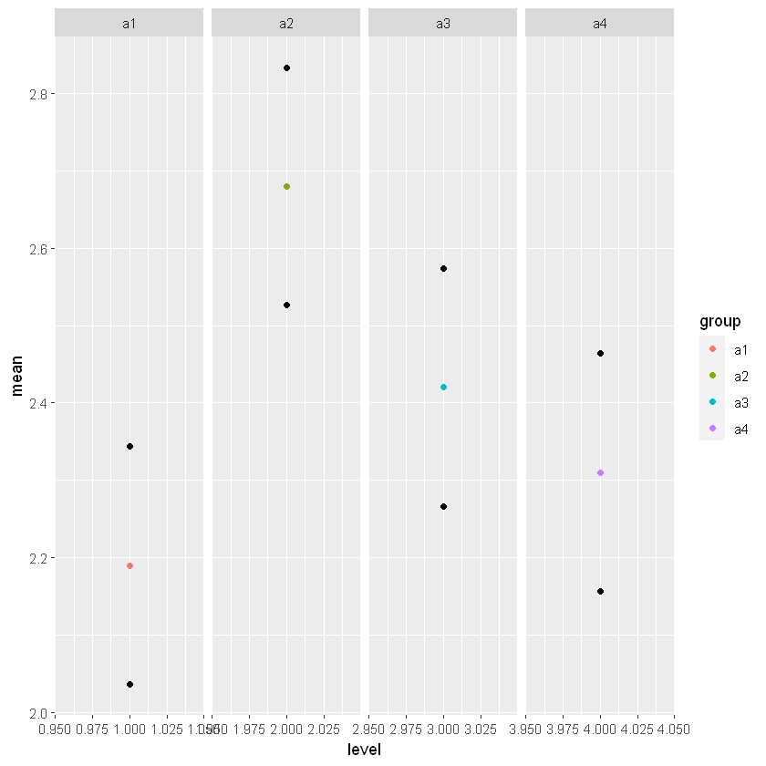

```r
ci %>% mutate(level = row_number()) %>%
    ggplot() + geom_point(aes(level, mean, color = group)) +
    geom_point(aes(level, lcl)) + geom_point(aes(level, ucl)) +
    facet_wrap(~ group, nrow = 1, scales = 'free_x')
```

  **모평균의 차이 $(\mu_i - \mu_j)$에 대한 추정값으로는 수준 $A_i$와 $A_j$에서의 특성값들의 평균의 차이인 $(\bar{x_{i.}} - \bar{x_{j.}})$이 적절**

  **$(\bar{x_{i.}} - \bar{x_{j.}})$의 분포는 $N(\mu_i - \mu_j, 2\sigma^2_E / r)$이며,**

  **여기서 $\sigma^2_E$는 불편추정량인 $MS_E$로 대체하여 계산하면 $(\mu_i - \mu_j)$의 $100(1-\alpha)$% 신뢰구간은**

  **$$(\bar{x_{i.}} - \bar{x_{j.}}) \pm t(\phi_E;\; \alpha/2)\sqrt{{{2MS_E}\over{r}}}$$로 주어지며, 신뢰구간에 0이 포함되어 있지 않으면,**

  **가설 $H_0: \mu_i - \mu_j = 0$ $\rightarrow$ $H_0: \mu_i = \mu_j$를 기각한다**

#### 따라서 $|\bar{x_{i.}} - \bar{x_{j.}}|$가 다음 조건을 만족하면 귀무가설을 기각

  $$|\bar{x_{i.}} - \bar{x_{j.}}| > t(\phi_E;\;\alpha/2)\sqrt{{{2MS_E}\over{r}}}$$

#### 여기서 우변, $t(\phi_E;\;\alpha/2)\sqrt{{{2MS_E}\over{r}}}$은 최소유의차 (LSD : least significant difference)

#### 사후분석은 제 1종 오류를 조정하는 방법에 따라 다양한 방법이 존재

1. **Tukey**
- **특징** : **비교 대상 표본수가 동일한 경우에만 사용 가능**, 모든 집단 조합에 대하여 분석
- **장점** : 표본수가 동일한 경우 가장 많이 사용되는 사후 분석 기법
- **단점** : 비교 대상 표본수가 동일하여하며, 표본수가 적을수록 정확도가 낮아짐
2. **Dunnett**
- **특징** : **하나의 집단을 기준으로 다른 집단들과 차이에 대하여 분석**, 양측 검정 가능
- **장점** : 1개의 대조군과 여러 실험군과의 비교를 하는 연구에 사용 가능
- **단점** : 모든 집단 조합에 대한 검정을 하지 않음
3. **Duncan**
- **특징** : **오차비율을 통제하지 않아 상대적으로 엄격하지 않은 기준**, 인접하는 평균값들을 단계적으로 비교
- **장점** : 엄격하지 않은 기준으로 통계적 유의성을 도출하기 쉬움
- **단점** : **기준이 엄격하지 않음 (제 1종 오류 발생활률을 통제하지 않음)**
4. **Fisher's LSD**
- **특징** : **가장 엄격하지 않은 방법**, 오차비율을 통제하지 않아 상대적으로 엄격하지 않은 기준 (최근에는 선호되지 않음)
- **장점** : 엄격하지 않은 기준으로 통계적 유의성을 도출하기 쉬움
- **단점** : **기준이 엄격하지 않음 (제 1종 오류 발생활률을 통제하지 않음)**, t-test를 여러번 하는 방법에 지나지 않음
5. **Bonferroni**
- **특징** : **응용 범위가 넓음 (모수, 비모수 적용 가능)**, Tukey보다 엄격하지만, Scheffe 보다는 관대 (전체적으로 1종 오류를 5%가 되게 만듬)
- **장점** : ANOVA, 다중 t-test, 비모수 검정 등에 적용 가능
- **단점** : **비교대상이 많아질수록 검정력이 약해짐**
6. **Scheffe**
- **특징** : **가장 보수적이고 엄격한 방식**
- **장점** : 엄격한 기준의 분석
- **단점** : 통계적으로 유의한 차이를 도출하기가 쉽지 않음
7. **Games-Howell**
- **특징** : **집단의 분산의 동질성이 확보되지 않았을 때 적용 가능**, Welch 분석 기법을 응용
- **장점** : **집단별 표본수가 다르거나, 분산의 동질성이 확보되지 않아도 적용 가능**
- **단점** : **표본수가 6개 미만일 경우, 제 1종 오류 발생률이 높아짐 (15개 이상 권장)**
8. **Tamhane T2**
- **특징** : **집단의 분산의 동질성이 확보되지 않았을 때 적용 가능**, 유의수준 조정 및 t분포를 기준으로 분석
- **장점** : Games-Howell보다 엄격한 기준
- **단점** : 샘플이 많아질 수록 1종 오류 발생률 증가
9. **Dunnett T3**
- **특징** : **집단의 분산의 동질성이 확보되지 않았을 때 적용 가능, 집단별 표본수가 동일한 경우에 적용 가능**, 유의수준 조정 및 t분포를 기준으로 분석
- **장점** : 집단별 표본수가 50개 미만인 경우 Games-Hoewll보다 검정력 우수
- **단점** : 집단별 표본수가 50개 이상일 경우 Games-Howell보다 1종 오류 발생률 증가

#### 각 경우별 많이 사용되는 사후검정 방법

1. **집단별 표본의 수와 분산이 동일한 경우** : Tukey $\rightarrow$ Dunnet $\rightarrow$ Duncan
2. **집단별로 표본의 수는 다르지만 분산의 동질성은 확보된 경우** : Fisher's LSD $\rightarrow$ Scheffe $\rightarrow$ Bonferroni
3. **집단별로 표본의 수도 다르고 분산의 동질성도 확보되지 않은 경우** : Games-Howell $\rightarrow$ Dunnett T3 $\rightarrow$ Tamhance T2

```r
TukeyHSD(aov.out)

### Dunnet Test
# set.seed(1234)
# DescTools::DunnettTest(x = wear.dat$wear, g = wear.dat$group)

### Duncan Test
# agricolae::duncan.test(aov.out, "factor(group)",console = T)

### Fisher's LSD
# agricolae::LSD.test(aov.out, "factor(group)", console = T)

### Bonferroni
# pairwise.t.test(x = wear.dat$wear, g = wear.dat$group, p.adjust.method= "bonferroni")

### Scheffe
# agricolae::scheffe.test(aov.out, "factor(group)", console = T)

### Games-Howell
# rstatix::games_howell_test(wear ~ group, data = wear.dat)

### Tamhane T2
# PMCMRplus::tamhaneT2Test(aov.out)

### Dunnett T3
# PMCMRplus::dunnettT3Test(aov.out)
```

```
  Tukey multiple comparisons of means
    95% family-wise confidence level

Fit: aov(formula = wear ~ factor(group), data = wear.dat)

$`factor(group)`
       diff         lwr         upr     p adj
a2-a1  0.49  0.19397708  0.78602292 0.0017496
a3-a1  0.23 -0.06602292  0.52602292 0.1509207
a4-a1  0.12 -0.17602292  0.41602292 0.6362891
a3-a2 -0.26 -0.55602292  0.03602292 0.0924227
a4-a2 -0.37 -0.66602292 -0.07397708 0.0136804
a4-a3 -0.11 -0.40602292  0.18602292 0.6943908
```

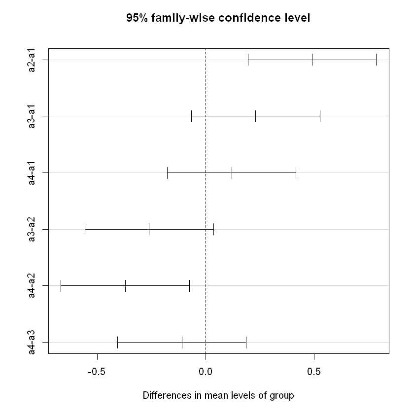

```r
# pairwise.t.test(wear, group, p.adj = "none")

plot(TukeyHSD(aov(wear ~ group), conf.level = 0.95))
```

## 03.04. 반복수가 같지 않은 실험

- 실제 일원배치법에서는 각 수준마다 반복수가 다른 데이터가 존재 (불균형 자료)
- 반복수가 같지 않은 일원배치법의 총실험횟수 $N$

$$N = r_1 + \dots + r_a$$

**반복수가 같지 않은 일원배치법의 자료의 구조, 구조모형과 분산분석은**

**반복수 $r$ 대신 각 수준 $i$에서의 반복수 $r_i$로 대체한 것을 제외하고는 같음**

#### $CT(=수정항) = {{T^2}\over{N}},\;\;\;T = \sum^a_{i=1}\sum^{r_i}_{j=1}x_{ij},\;\;\; N = \sum^a_{i=1}r_i$일 때,

$$SS_T = \sum_i \sum_j x^2_{ij} - CT$$$$SS_A = \sum_i {{T^2_{i.}}\over{r_i}} - CT$$$$SS_E = SS_T - SS_A$$

#### 자유도 계산

$$\phi_T = N-1$$$$\phi_A = a-1$$$$\phi_E = \phi_T - \phi_A = N-a$$

#### 분산분석표

| 요인 | 제곱합 | 자유도 | 평균제곱 | $F_0$ | $F(\alpha)$ |
| --- | --- | --- | --- | --- | --- |
| $A$ | $SS_A$ | $a$-$1$ | $MS_A$ | ${{MS_A}\over{MS_E}}$ | $F(a-1, N-a;\;\;\alpha)$ |
| $E$ | $SS_E$ | $N$-$a$ | $MS_E$ |  |  |
| $T$ | $SS_T$ | $N$-$1$ |  |  |  |

### 식이요법 예시

- 실험목적 : 네 종류의 식단 $(A_1, \dots, A_4)$에 따른 식이요법이 동물의 혈액응고시간에 영향을 주는가를 파악
- 실험의 랜덤화 및 자료의 수집
  - 실험단위를 처리에 랜덤하게 배리
    1. 24마리의 동물에 1 ~ 24까지 일렬번호 지정
    2. 1 ~ 24까지 번호를 랜덤으로 선택하여 순서 지정
    3. 처음 6개에 $A_1$, $\dots$, 네 번째 6개에 $A_4$ 배치
  - 혈액응고시간 측정
    - $A_1$에 할당된 실험체 하나가 제외

      $r_1 = 5, r_2 =6, r_3 = 6, r_4 = 6$

```r
a1 <- c(62, 60, 63, 59, 61)
a2 <- c(63, 67, 71, 64, 65, 66)
a3 <- c(68, 66, 71, 67, 68, 68)
a4 <- c(56, 62, 60, 61, 63, 64)
y <- c(a1, a2, a3, a4)
x <- c("a1", "a2", "a3", "a4"); x <- rep(x, c(5, 6, 6, 6))
```

- 귀무가설 기각 $\rightarrow$ **식이요법이 달라도 혈액응고시간에 차이가 없지 않음**

```r
anova <- aov(y ~ x)
tidy(anova)
```

A tibble: 2 × 6

| term <chr> | df <dbl> | sumsq <dbl> | meansq <dbl> | statistic <dbl> | p.value <dbl> |
| --- | --- | --- | --- | --- | --- |
| x | 3 | 218.6087 | 72.869565 | 13.31271 | 6.490997e-05 |
| Residuals | 19 | 104.0000 | 5.473684 | NA | NA |

- $mu_1$과 $\mu_2$, $\mu_3$은 다르며, $\mu_2$와 $\mu_4$는 다르고, $\mu_3$과 $\mu_4$는 다름

```r
pairwise.t.test(y, x, p.adjust.method = "none")
```

```
	Pairwise comparisons using t tests with pooled SD

data:  y and x

   a1      a2     a3
a2 0.0022  -      -
a3 9.1e-05 0.1551 -
a4 1.0000  0.0015 5.3e-05

P value adjustment method: none
```

- 수준간 등분산성 검정 $\rightarrow$ 등분산성 만족

```r
bartlett.test(y ~ x)
```

```
	Bartlett test of homogeneity of variances

data:  y by x
Bartlett's K-squared = 2.4724, df = 3, p-value = 0.4803
```

- 잔차 등분산성 검정 $\rightarrow$ 등분산성 만족
  - 각 예측치에서 잔차는 특정한 패턴을 보이지 않음

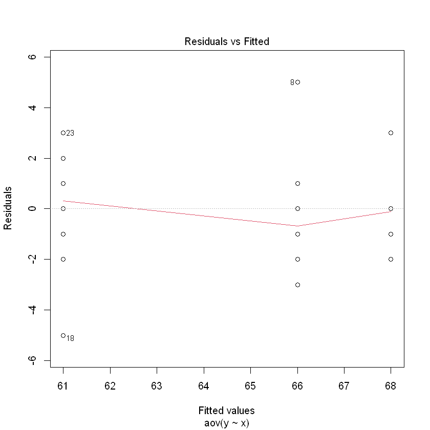

```r
plot(anova, 1)
```

```r
shapiro.test(y)
```

```
	Shapiro-Wilk normality test

data:  y
W = 0.97847, p-value = 0.8786
```

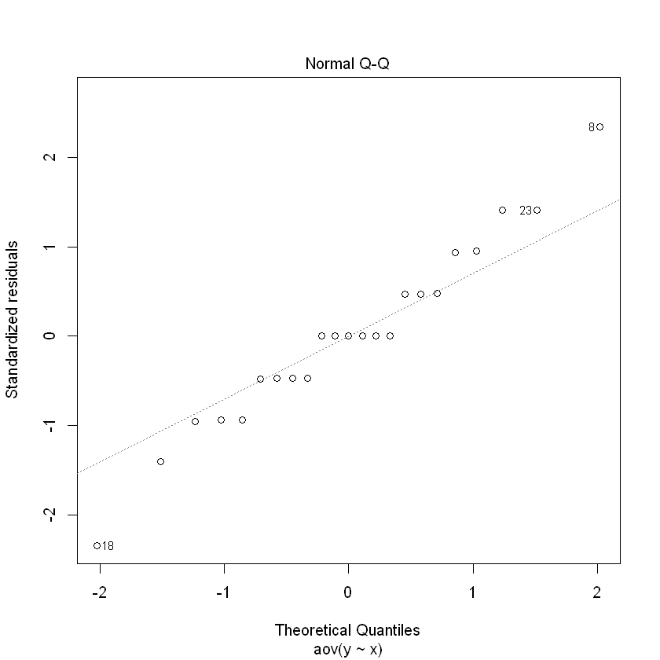

```r
plot(anova, 2)
```

## 03.05. 랜덤모형

- 요인의 수준이 고정되지 않고 랜덤하게 선택된 구조모형 (실험일, 원료 로트 등)
  - **각각의 수준에서의 값들이 기술적인 의미를 갖지 못하여, 수준들 간 차이가 있는지를 산포의 크기로 판단**
- **요인 수준들 간 산포가 존재해서 이질적인 경우에는, 자료의 총분산 중에서 순수하게 수준 간의 산포에만 기인하는 분산의 비율인 기여율의 추정에 관심**
- **랜덤모형의 구조모형은 요인$A$의 수준들이 랜덤하기 때문에, 분산이 $\sigma^2_A$인 정규분포를 따름**

$$x_{ij} = \mu + \alpha_i+\epsilon_{ij},\;\;\;i=1, 2, \dots,a;\;\;\;j=1,2,\dots,r$$$$\alpha_i \sim N(0, \sigma^2_A)이고,\;서로\;독립$$$$\epsilon_i \sim N(0, \sigma^2_E)이고,\;서로\;독립$$$$\alpha_i와\;\epsilon_{ij}\;:\;서로\;독립$$

- **일원배치법인 경우 랜덤모형에서의 변동의 계산, 자유도의 계산, F검정, 분산분석표는 은 고정모형과 동일**

#### 가설

$$H_0 : \sigma^2_A=0\;(랜덤요인이\;동질적)$$$$H_1 : \sigma^2_A>0\;(랜덤요인이\;이질적)$$

- **분산분석을 통한 가설검정결과 귀무가설을 기각하게 되면 $\sigma^2_A$을 추정**
- 평균제곱 $MS$의 기댓값

$$E(MS_E) = \sigma^2_E$$$$E(MS_A) = \sigma^2_E + r\sigma^2_A$$

- **$\sigma^2_E$의 불편추정치 $\hat{\sigma^2_E}$와, $\sigma^2_A$의 불편추정치 $\hat{\sigma^2_A}$**

$$\hat{\sigma^2_E} = MS_E$$$$\hat{\sigma^2_A} = {1\over r}(MS_A - MS_E)$$

- **랜덤모형의 구조모형에서의 총분산은, 요인 $A$의 수준에서의 분산과, 오차의 분산의 합으로 표현**

$$Var(x_{ij}) = Var(\alpha_i) + Var(\epsilon_{ij}) = \sigma^2_A + \sigma^2_E$$

- **총분산의 추정치의 $\sigma^2_A$와 $\sigma^2_E$를 각각의 불편추정치 $\hat{\sigma^2_A}$, $\hat{\sigma^2_E}$로 대체하여**

$$\hat{Var(x_{ij})} = \hat{\sigma^2_A} + \hat{\sigma^2_E}$$

- **따라서 자료의 총분산 중 요인 $A$의 수준 간 산포에만 기인하는 비율인 기여율 $\rho$**

$$\rho = {{\sigma^2_A}\over{\sigma^2_A + \sigma^2_E}} \times 100%$$$$\hat{\rho} = {{\hat{\sigma^2_A}}\over{\hat{Var(x_{ij})}}}\times100%$$

#### 약품회사 예시

- 매년 원자재의 수백 개의 배치(batch)를 정제
- 수백 개의 배치 중 5개의 배치를 랜덤하게 선택하고, 선택된 배치당 3개의 시료를 채취하여 순도 측정

```r
b1 <- c(74, 76, 75)
b2 <- c(68, 71, 72)
b3 <- c(75, 77, 77)
b4 <- c(72, 74, 73)
b5 <- c(79, 81, 79)
y <- c(b1, b2, b3, b4, b5)
x <- c("b1", "b2", "b3", "b4", "b5"); x <- rep(x, c(3, 3, 3, 3, 3))

df = tibble(y, x); df %>% head
```

A tibble: 6 × 2

| y <dbl> | x <chr> |
| --- | --- |
| 74 | b1 |
| 76 | b1 |
| 75 | b1 |
| 68 | b2 |
| 71 | b2 |
| 72 | b2 |

- 분산분석 : 배치 간의 산포가 존재하여, 배치가 동질적이 아님

```r
anova <- aov(y ~ factor(x), df)
tidy(anova)
```

A tibble: 2 × 6

| term <chr> | df <dbl> | sumsq <dbl> | meansq <dbl> | statistic <dbl> | p.value <dbl> |
| --- | --- | --- | --- | --- | --- |
| factor(x) | 4 | 147.7333 | 36.93333 | 20.51852 | 8.24639e-05 |
| Residuals | 10 | 18.0000 | 1.80000 | NA | NA |

```r
library(lme4)
```

```r
lmer(y ~ (1|x))
```

```
Linear mixed model fit by REML ['lmerMod']
Formula: y ~ (1 | x)
REML criterion at convergence: 62.7527
Random effects:
 Groups   Name        Std.Dev.
 x        (Intercept) 3.422
 Residual             1.342
Number of obs: 15, groups:  x, 5
Fixed Effects:
(Intercept)
      74.87
```

```r
3.422^2/(3.422^2 + 1.342^2)
```

0.866704344474241